# IE360: Statistical Forecasting and Time Series, Spring 2020 Term Project

#### *Group 12: Sadullah Gültekin, Yusuf Başpınar, Serhat Yılmaz, Bahadır Hocamoğlu*

#### *July 5, 2020*

## Introduction

In this project, we are given a time series data collected from Trendyol e-commerce platform. There is data for approximately 3,5 months for different products. The products are given on a daily basis. We are asked to make a prediction for next day’s sold counts for each given product as accurately as possible. In the data there are eleven attributes. They are;

- product ID (unique id for each product)
- price of the product
- date
- sale count
- favored count (number of times, the product is favored by a customer)
- basket count (number of times, the product is added to the basket by a customer)
- category sold (number of times the product with the same category is sold)
- brand sold (number of times the product with the same brand is sold)
- category visit (number of visits done to the same category)
- trendyol visit (number of visits done to Trendyol)

## Approach

At the starting parts of the project, we didn’t use any of these attributes. Simply, we looked to the sold count and made a prediction using tree different model using “statsmodel” library of python. These models were Autoregressive model, Moving Average Model and ARIMA model. We were simply performing a procedure to decide which model works better for predicting the last 15 days. The procedure is as follows: we used all data until 15 days ago to train a model, and use it to make a prediction for 14 days ago. Then we did the same process for 14 days, 13 days, etc. After running 15 different prediction iterations, we took the average value of the error done at each prediction. In the calculation of error, we used MSE(Minimum Squared Error). We run the procedure described above for 3 models and selected the one with the lowest error to make a prediction for the next day.

When the last submission got closer, we found that there is a auto arima function in the python, and using this function we can utilize more models using a simple script. So we trained different models for different products using this model. One advantage of this model was using all variables to make a prediction. Using this model, we became able to calculate the values of differencings. In this multivariate model, we used endogenous variables and exogenous variables. Endogenous variable was the sold count, because we are trying to predict the value of this attribute. Exogenous variables were visit count and basket count, because we are making use of these variables to predict endogenous variables. However, we needed to have the values of exogenous variables corresponding to the next day. So, we made a prediction for these variables, and used the predictions as an input for sold count prediction model. Using this methodology, we made an average success. Reported the code, plot graphs and heatmaps in the code below.

## Results

| 16-May | 17-May | 18-May | 19-May | 20-May | 21-May | 22-May | 23-May | 24-May | 25-May | 26-May | 27-May | 28-May | 29-May | 30-May | 31-May | 1-June | 2-June | 3-June | 4-June | 5-June | 6-June | 7-June | 8-June | 9-June | 10-June | 11-June | 12-June | 13-June | Final |
| --- | --- | --- | --- | --- | --- | --- | --- | --- | --- | --- | --- | --- | --- | --- | --- | --- | --- | --- | --- | --- | --- | --- | --- | --- | --- | --- | --- | --- | --- |
| 21 | 17 | 26 | 22 | 11 | 12 | 18 | 18 | 10 | 16 | 23 | 19 | 24 | 0 | 22 | 12 | 15 | 19 | 21 | 10 | 25 | 24 | 15 | 10 | 0 | 22 | 20 | 15 | 10 | 477 |

## Code

```python
from pprint import pprint
from random import choice
import pandas as pd
import seaborn as sns
import numpy as np
import matplotlib.pyplot as plt

from statsmodels.tsa.stattools import adfuller
import pmdarima as pmd

from warnings import filterwarnings; filterwarnings('ignore')
```

```python
data = pd.read_csv('data.csv')
data_grouped_by_id = data.groupby(by='product_content_id')
```

```
Product 85004:
       sold_count   visit_count  favored_count  basket_count  category_sold  \
count  107.000000    107.000000     107.000000    107.000000     107.000000
mean    58.439252   2645.252336     254.196262    283.943925    2294.785047
std     25.858533   1254.785407     182.108170    133.052822    1820.475006
min     11.000000   1003.000000      86.000000     35.000000     370.000000
25%     39.000000   1886.500000     140.500000    180.000000     493.500000
50%     57.000000   2406.000000     228.000000    259.000000    2579.000000
75%     72.000000   3001.000000     308.000000    355.000000    3718.500000
max    165.000000  10088.000000    1237.000000    809.000000    7163.000000

       category_brand_sold  category_visits     ty_visits
count           107.000000       107.000000  1.070000e+02
mean            184.299065    281447.177570  1.104297e+08
std             204.173586     73290.972133  2.660930e+07
min               8.000000     41841.000000  1.580350e+07
25%              13.000000    224362.500000  9.673313e+07
50%             169.000000    292790.000000  1.102683e+08
75%             277.500000    339570.500000  1.273878e+08
max            1073.000000    439415.000000  1.741070e+08
```

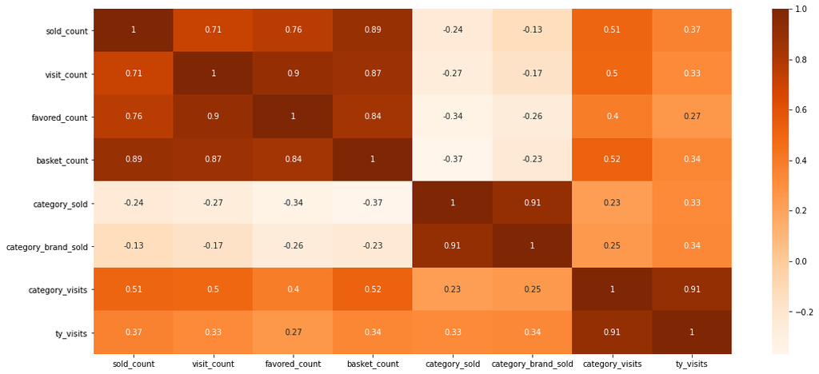

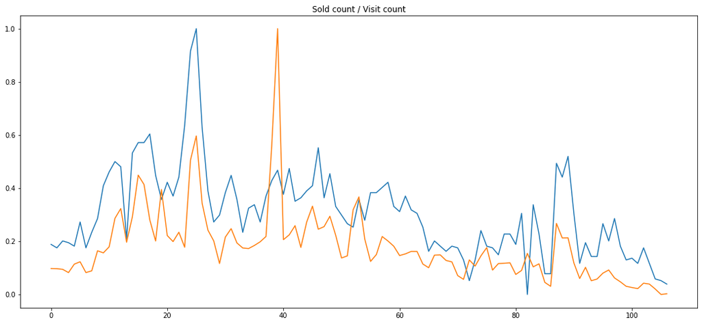

[figure not shown]

```
Product 3904356:
       sold_count  visit_count  favored_count  basket_count  category_sold  \
count  107.000000   107.000000     107.000000    107.000000     107.000000
mean     0.009346    41.074766       0.383178      0.401869     765.485981
std      0.096674    40.204595       0.735166      0.763060     266.566653
min      0.000000     0.000000       0.000000      0.000000      78.000000
25%      0.000000     2.000000       0.000000      0.000000     625.000000
50%      0.000000    27.000000       0.000000      0.000000     714.000000
75%      0.000000    69.500000       1.000000      1.000000     899.500000
max      1.000000   177.000000       3.000000      4.000000    1659.000000

       category_brand_sold  category_visits     ty_visits
count           107.000000     1.070000e+02  1.070000e+02
mean             27.822430     5.465165e+05  1.104297e+08
std              36.051277     2.274902e+05  2.660930e+07
min               1.000000     3.968600e+04  1.580350e+07
25%               6.000000     3.432695e+05  9.673313e+07
50%              13.000000     5.413540e+05  1.102683e+08
75%              30.000000     7.218450e+05  1.273878e+08
max             165.000000     1.090216e+06  1.741070e+08
```

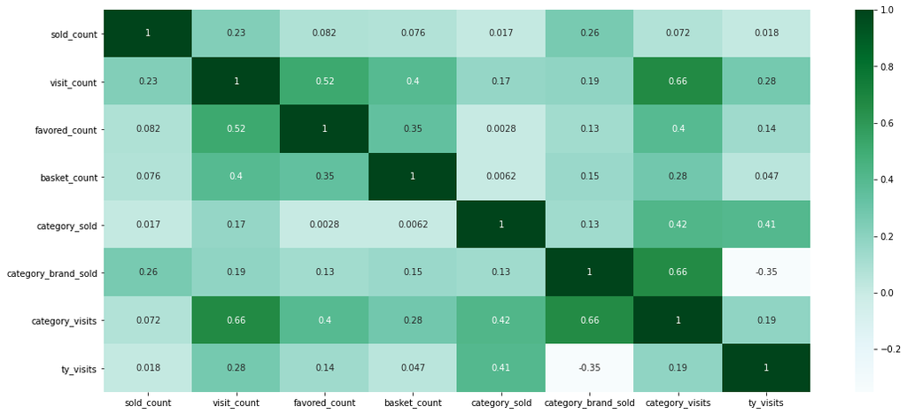

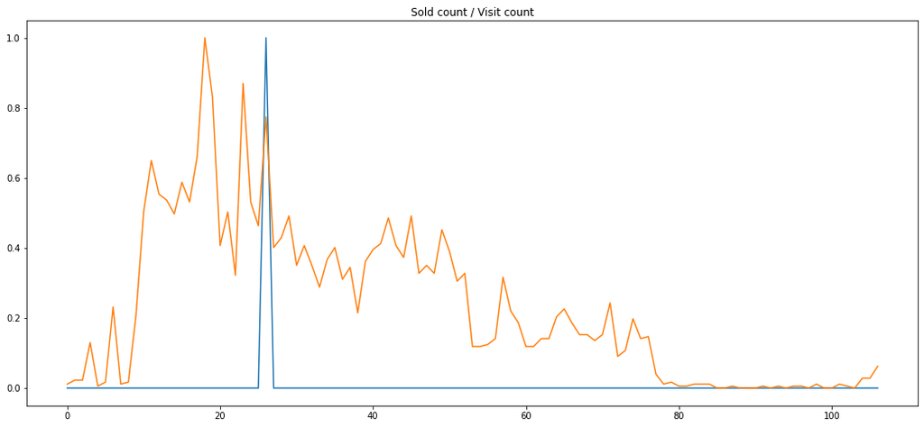

[figure not shown]

```
Product 4066298:
       sold_count   visit_count  favored_count  basket_count  category_sold  \
count  107.000000    107.000000     107.000000    107.000000     107.000000
mean   197.364486   2564.476636      85.981308    408.130841     863.551402
std     99.073290   1314.270070      46.347331    222.868778     644.449527
min     23.000000   1152.000000      29.000000     34.000000     123.000000
25%    143.500000   1916.000000      63.000000    295.000000     229.000000
50%    175.000000   2295.000000      74.000000    354.000000     962.000000
75%    222.500000   2624.000000      99.500000    467.000000    1333.500000
max    824.000000  11065.000000     419.000000   2062.000000    2695.000000

       category_brand_sold  category_visits     ty_visits
count           107.000000       107.000000  1.070000e+02
mean            321.149533     46925.943925  1.104297e+08
std             300.463786     14871.122038  2.660930e+07
min              35.000000      4719.000000  1.580350e+07
25%              48.000000     37381.000000  9.673313e+07
50%             371.000000     44900.000000  1.102683e+08
75%             490.000000     54164.000000  1.273878e+08
max            1460.000000    113618.000000  1.741070e+08
```

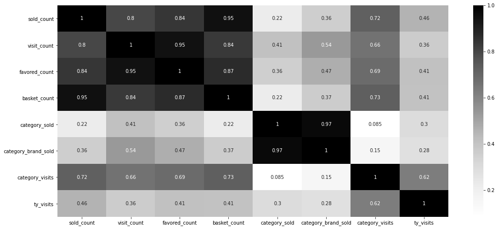

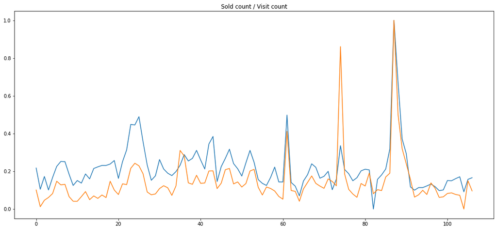

[figure not shown]

```
Product 5926527:
       sold_count  visit_count  favored_count  basket_count  category_sold  \
count  107.000000   107.000000     107.000000    107.000000     107.000000
mean     0.626168   236.934579       7.196262      4.448598    1288.738318
std      0.863553   282.366558       8.017009      4.800223    1225.694038
min      0.000000     4.000000       0.000000      0.000000      98.000000
25%      0.000000    86.500000       3.000000      2.000000     304.500000
50%      0.000000   171.000000       5.000000      3.000000     923.000000
75%      1.000000   284.500000       7.500000      5.500000    1876.500000
max      5.000000  2324.000000      58.000000     34.000000    6278.000000

       category_brand_sold  category_visits     ty_visits
count           107.000000     1.070000e+02  1.070000e+02
mean            864.158879     3.108468e+05  1.104297e+08
std             786.637220     2.281872e+05  2.660930e+07
min              70.000000     5.649200e+04  1.580350e+07
25%             196.500000     1.588130e+05  9.673313e+07
50%             742.000000     2.212440e+05  1.102683e+08
75%            1348.500000     3.871005e+05  1.273878e+08
max            4643.000000     1.119817e+06  1.741070e+08
```

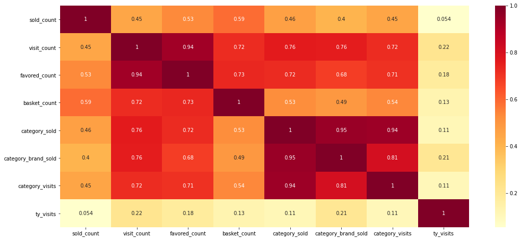

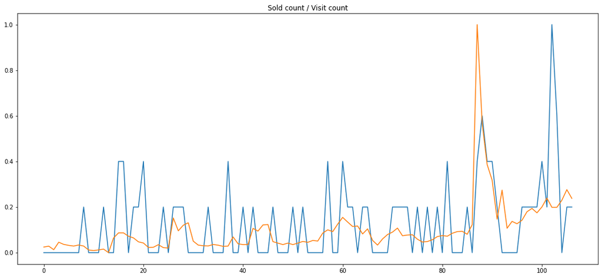

[figure not shown]

```
Product 6676673:
       sold_count   visit_count  favored_count  basket_count  category_sold  \
count  107.000000    107.000000     107.000000    107.000000     107.000000
mean   373.261682  19997.785047     293.261682   1577.084112    1997.504673
std    152.769424   3805.210033      87.217072    529.427122    1729.044187
min     57.000000  14184.000000     123.000000    210.000000       2.000000
25%    262.000000  17530.500000     237.000000   1193.000000     348.500000
50%    351.000000  19006.000000     272.000000   1426.000000    2663.000000
75%    463.000000  21316.500000     328.000000   1910.000000    3147.500000
max    841.000000  33418.000000     692.000000   3324.000000   10275.000000

       category_brand_sold  category_visits     ty_visits
count           107.000000       107.000000  1.070000e+02
mean            336.700935    344977.196262  1.104297e+08
std             313.139526    108040.223377  2.660930e+07
min              -1.000000       458.000000  1.580350e+07
25%              21.000000    284241.500000  9.673313e+07
50%             386.000000    351737.000000  1.102683e+08
75%             566.000000    405420.000000  1.273878e+08
max            1044.000000    665850.000000  1.741070e+08
```

[12 more figures not shown]

```python
features = [
    'sold_count',
    'visit_count',
    'favored_count',
    'basket_count',
    'category_sold',
    'category_brand_sold',
    'category_visits',
    'ty_visits',]

for product in data_grouped_by_id:
    product_id = product[0]
    product_data = product[1][features]
    print(f'Product {product_id}:')
    print(product_data.describe())

    corr = np.corrcoef(product_data.T.replace(np.nan, 0))
    plt.figure(figsize = (18,8))
    heatmap = sns.heatmap(
        corr,
        cmap=choice(['Greys', 'Purples', 'Blues', 'Greens', 'Oranges', 'Reds',
            'YlOrBr', 'YlOrRd', 'OrRd', 'PuRd', 'RdPu', 'BuPu',
            'GnBu', 'PuBu', 'YlGnBu', 'PuBuGn', 'BuGn', 'YlGn']),
        annot=True,
        xticklabels=features,
        yticklabels=features)
    plt.show()

    sold_count = product_data['sold_count'].to_numpy()
    visit_count = product_data['visit_count'].to_numpy()
    basket_count = product_data['basket_count'].to_numpy()

    sold_count = (sold_count - np.min(sold_count)) / (np.max(sold_count) - np.min(sold_count))
    visit_count = (visit_count - np.min(visit_count)) / (np.max(visit_count) - np.min(visit_count))
    basket_count = (basket_count - np.min(basket_count)) / (np.max(basket_count) - np.min(basket_count))

    plt.figure(figsize = (18,8))
    plt.title('Sold count / Visit count')
    plt.plot(range(len(sold_count)), sold_count)
    plt.plot(range(len(visit_count)), visit_count)
    plt.show()

    plt.figure(figsize = (18,8))
    plt.title('Sold count / Basket count')
    plt.plot(range(len(sold_count)), sold_count)
    plt.plot(range(len(basket_count)), visit_count)
    plt.show()

    print()
```

```python
print(data.head())
data.describe()
```

```
Unnamed: 0   price  event_date  product_content_id  sold_count  \
0         855  101.72  2020-03-21            32939029         119
1         848   64.94  2020-03-21             4066298         197
2         849   -1.00  2020-03-21             3904356           0
3         850  222.84  2020-03-21             7061886          22
4         854   39.99  2020-03-21            31515569         494

   visit_count  favored_count  basket_count  category_sold  \
0         5012            325           607            182
1         2152             70           509            203
2            2              0             0            942
3         1821             68           101            113
4        23025            937          4978           1298

   category_brand_sold  category_visits  ty_visits
0                   78            56314   61228451
1                   48            39446   61228451
2                  148           953347   61228451
3                    8           124712   61228451
4                   67           522917   61228451
```

|  | Unnamed: 0 | price | product_content_id | sold_count | visit_count | favored_count | basket_count | category_sold | category_brand_sold | category_visits | ty_visits |
| --- | --- | --- | --- | --- | --- | --- | --- | --- | --- | --- | --- |
| count | 856.000000 | 856.000000 | 8.560000e+02 | 856.000000 | 856.000000 | 856.000000 | 856.000000 | 856.000000 | 856.000000 | 8.560000e+02 | 8.560000e+02 |
| mean | 427.500000 | 85.071741 | 1.152192e+07 | 175.584112 | 7553.419393 | 243.785047 | 823.066589 | 1658.367991 | 405.745327 | 3.297426e+05 | 1.104297e+08 |
| std | 247.250211 | 71.875259 | 1.213934e+07 | 240.367126 | 10450.522152 | 325.476386 | 1387.595680 | 2262.036796 | 583.570948 | 3.053884e+05 | 2.650015e+07 |
| min | 0.000000 | -1.000000 | 8.500400e+04 | 0.000000 | 0.000000 | 0.000000 | 0.000000 | -1.000000 | -1.000000 | -1.000000e+00 | 1.580350e+07 |
| 25% | 213.750000 | 29.990000 | 4.025812e+06 | 2.000000 | 465.000000 | 13.750000 | 10.750000 | 331.000000 | 26.000000 | 8.595125e+04 | 9.654915e+07 |
| 50% | 427.500000 | 75.610000 | 6.301600e+06 | 79.000000 | 2568.000000 | 126.000000 | 304.000000 | 788.000000 | 105.000000 | 2.416155e+05 | 1.102683e+08 |
| 75% | 641.250000 | 132.237500 | 1.317531e+07 | 227.250000 | 11308.250000 | 301.000000 | 953.000000 | 1843.750000 | 555.750000 | 4.331748e+05 | 1.276706e+08 |
| max | 855.000000 | 355.150000 | 3.293903e+07 | 1461.000000 | 53707.000000 | 2090.000000 | 9789.000000 | 13393.000000 | 4643.000000 | 1.538398e+06 | 1.741070e+08 |

```python
def arimamodel(timeseriesarray, exogenous=None, trace=False):
    return pmd.auto_arima(  # equivalent to auto.arima in R
        timeseriesarray,
        exogenous=exogenous,
        start_p=0, start_q=0,
        test="adf",
        d=pmd.arima.ndiffs(timeseriesarray, max_d=3),
        max_order=15,
        trace=trace)
```

```python
prediction_models_for_visit_counts = {
    product_id: arimamodel(
        product_data['visit_count'],
        trace=True
    )
    for product_id, product_data in data_grouped_by_id
    }
prediction_models_for_basket_counts = {
    product_id: arimamodel(
        product_data['basket_count'],
        trace=True
    )
    for product_id, product_data in data_grouped_by_id
    }
```

[output not shown]

[output cut: 144 more lines]

[output not shown]

```python
prediction_models = {
    product_id: arimamodel(
        product_data['sold_count'],
        exogenous=product_data[['visit_count', 'basket_count']],
        trace=True
    )
    for product_id, product_data in data_grouped_by_id
    }

print("Optimal ARIMA models for each product:\n")
for id, model in prediction_models.items():
    print(f"product {id}:\t{str(model)}")
```

[output not shown]

[output cut: 69 more lines]

```
      scoring='mse', scoring_args=None, seasonal_order=(0, 0, 0, 0),
      start_params=None, suppress_warnings=False, trend=None,
      with_intercept=True)
product 7061886:	ARIMA(maxiter=50, method='lbfgs', order=(1, 1, 1), out_of_sample_size=0,
      scoring='mse', scoring_args=None, seasonal_order=(0, 0, 0, 0),
      start_params=None, suppress_warnings=False, trend=None,
      with_intercept=True)
product 31515569:	ARIMA(maxiter=50, method='lbfgs', order=(1, 0, 0), out_of_sample_size=0,
      scoring='mse', scoring_args=None, seasonal_order=(0, 0, 0, 0),
      start_params=None, suppress_warnings=False, trend=None,
      with_intercept=True)
product 32939029:	ARIMA(maxiter=50, method='lbfgs', order=(0, 1, 0), out_of_sample_size=0,
      scoring='mse', scoring_args=None, seasonal_order=(0, 0, 0, 0),
      start_params=None, suppress_warnings=False, trend=None,
      with_intercept=False)
```

```python
predictions_for_visit_counts = {
    product_id: model.predict(1)[0]
    for product_id, model in prediction_models_for_visit_counts.items()}

predictions_for_basket_counts = {
    product_id: model.predict(1)[0]
    for product_id, model in prediction_models_for_basket_counts.items()}

predictions = {
    product_id: max(0.0, model.predict(1, exogenous=[
        [predictions_for_visit_counts[product_id],
        predictions_for_basket_counts[product_id]]])[0])
    for product_id, model in prediction_models.items()}

print("Predictions for the next day for each product:\n")
for id, prediction in predictions.items():
    print(f"product {id}:\t{prediction}")
```

```
Predictions for the next day for each product:

product 85004:	28.061045227479514
product 3904356:	0.0024644188774621202
product 4066298:	180.2043280296766
product 5926527:	1.059184334556134
product 6676673:	517.9523764316581
product 7061886:	36.767480353618396
product 31515569:	378.7380921241957
product 32939029:	0.0
```